# Data

# Task

The first task is to predict which recipes are from asian cuisines. For the purpose of this task, the following cuisines will be labeled as asian: 'indian', 'japanese', 'chinese', 'filipino', 'thai', 'korean', and 'vietnamese'. In other words, a classification model will be trained on the data and evaluated on a holdout test set, and the classification accuracy will be reported. The 1000 most frequently occurring ingredients will be used as features for this problem, and the values in the feature matrix will be indicators as to whether an ingredient is present in a given recipe.

The second task is to identify which ingredients are most important when determining whether a recipe is asian or not. Many cuisines include similar ingredients. For example, onions may be used in Chinese stir frys, French sauces, and Mexican tacos. However, other ingredients are more unique to certain cuisines. For example, one would not expect Mexican masa to appear in a Thai dish. Thus, the goal of this task is to discover the most defining ingredients in asian cuisine.

### Data Preperation

```python
import pandas as pd
import numpy as np

from sklearn import decomposition
from sklearn.experimental import enable_iterative_imputer
from sklearn.impute import IterativeImputer
from sklearn.model_selection import train_test_split, cross_val_score, GridSearchCV, KFold
import warnings
warnings.filterwarnings('ignore')

import matplotlib.pyplot as plt
from matplotlib.colors import ListedColormap
```

```python
# The test data has no labels, so a train/test split will be performed on the training data
df= pd.read_json("train.json")

ingredients = df.ingredients.explode().unique()

recipeIngredients = df.ingredients.explode()
countIngredients = recipeIngredients.value_counts().reset_index()
countIngredients = countIngredients.rename(columns = {"index":"Ingredient", "ingredients":"weight"})

print(set(df['cuisine']))
```

```
{'italian', 'russian', 'korean', 'moroccan', 'greek', 'filipino', 'japanese', 'mexican', 'jamaican', 'vietnamese', 'brazilian', 'spanish', 'british', 'southern_us', 'cajun_creole', 'irish', 'thai', 'indian', 'french', 'chinese'}
```

```python
# Check distribution of the cuisines
from collections import Counter
cuisine_counts = Counter(df['cuisine'])
cuisine_counts
```

```
Counter({'greek': 1175,
         'southern_us': 4320,
         'filipino': 755,
         'indian': 3003,
         'jamaican': 526,
         'spanish': 989,
         'italian': 7838,
         'mexican': 6438,
         'chinese': 2673,
         'british': 804,
         'thai': 1539,
         'vietnamese': 825,
         'cajun_creole': 1546,
         'brazilian': 467,
         'french': 2646,
         'japanese': 1423,
         'irish': 667,
         'korean': 830,
         'moroccan': 821,
         'russian': 489})
```

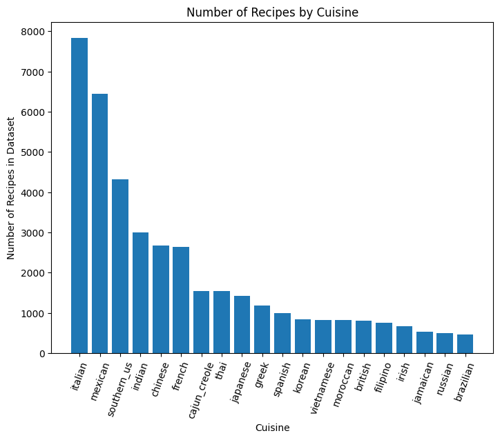

```python
# Vizualize recipe distributions
items = sorted(cuisine_counts.items(), key=lambda x: -x[1])
fig = plt.figure()
ax = fig.add_axes([0,0,1,1])
ax.bar([item[0] for item in items],[item[1] for item in items])

plt.title("Number of Recipes by Cuisine")
plt.xlabel("Cuisine")
plt.ylabel("Number of Recipes in Dataset")
plt.xticks(rotation = 70) # Rotates X-Axis Ticks by 45-degrees
plt.show()
```

```python
# Convert the data to a binary classification problem: asian cuisine or not
asian_cuisines = ['indian', 'japanese', 'chinese', 'filipino', 'thai', 'korean', 'vietnamese']

df['cuisine'] = df['cuisine'].map(lambda x: 'Asian' if x in asian_cuisines else 'Not Asian')
print(set(df['cuisine']))
cuisines = list(set(df['cuisine']))
```

```
{'Asian', 'Not Asian'}
```

```python
# Slightly imbalanced classes
Counter(df['cuisine'])
```

```
Counter({'Not Asian': 28726, 'Asian': 11048})
```

```python
# Ingredient counts sorted by frequency
countIngredients
```

|  | Ingredient | weight |
| --- | --- | --- |
| 0 | salt | 18049 |
| 1 | olive oil | 7972 |
| 2 | onions | 7972 |
| 3 | water | 7457 |
| 4 | garlic | 7380 |
| ... | ... | ... |
| 6709 | sauerkraut juice | 1 |
| 6710 | no-calorie sweetener | 1 |
| 6711 | Bob Evans Italian Sausage | 1 |
| 6712 | extra firm silken tofu | 1 |
| 6713 | crushed cheese crackers | 1 |

6714 rows × 2 columns

```python
# Build a feature matrix using top 1000 most common ingredients
topIngredients = countIngredients[:1000]['Ingredient']
topIngredients
for i in topIngredients:
    df[i] = df['ingredients'].apply(lambda x: 1 if i in x else 0)
```

```python
df.drop(columns='ingredients', inplace=True)
labels = df['cuisine']
df.drop(columns='cuisine', inplace=True)
df.drop(columns='id', inplace=True)

features = df
features
```

|  | salt | olive oil | onions | water | garlic | sugar | garlic cloves | butter | ground black pepper | all-purpose flour | ... | gari | fruit | plain low-fat yogurt | thai green curry paste | great northern beans | seedless cucumber | salad greens | organic vegetable broth | duck | file powder |
| --- | --- | --- | --- | --- | --- | --- | --- | --- | --- | --- | --- | --- | --- | --- | --- | --- | --- | --- | --- | --- | --- |
| 0 | 0 | 0 | 0 | 0 | 1 | 0 | 0 | 0 | 0 | 0 | ... | 0 | 0 | 0 | 0 | 0 | 0 | 0 | 0 | 0 | 0 |
| 1 | 1 | 0 | 0 | 0 | 0 | 0 | 0 | 0 | 1 | 0 | ... | 0 | 0 | 0 | 0 | 0 | 0 | 0 | 0 | 0 | 0 |
| 2 | 1 | 0 | 0 | 0 | 0 | 0 | 0 | 1 | 0 | 0 | ... | 0 | 0 | 0 | 0 | 0 | 0 | 0 | 0 | 0 | 0 |
| 3 | 1 | 0 | 0 | 1 | 0 | 0 | 0 | 0 | 0 | 0 | ... | 0 | 0 | 0 | 0 | 0 | 0 | 0 | 0 | 0 | 0 |
| 4 | 1 | 0 | 1 | 1 | 0 | 0 | 0 | 1 | 0 | 0 | ... | 0 | 0 | 0 | 0 | 0 | 0 | 0 | 0 | 0 | 0 |
| ... | ... | ... | ... | ... | ... | ... | ... | ... | ... | ... | ... | ... | ... | ... | ... | ... | ... | ... | ... | ... | ... |
| 39769 | 1 | 0 | 0 | 0 | 0 | 0 | 0 | 1 | 0 | 1 | ... | 0 | 0 | 0 | 0 | 0 | 0 | 0 | 0 | 0 | 0 |
| 39770 | 0 | 0 | 0 | 0 | 0 | 0 | 0 | 0 | 0 | 0 | ... | 0 | 0 | 0 | 0 | 0 | 0 | 0 | 0 | 0 | 0 |
| 39771 | 1 | 0 | 0 | 0 | 0 | 1 | 0 | 1 | 0 | 0 | ... | 0 | 0 | 0 | 0 | 0 | 0 | 0 | 0 | 0 | 0 |
| 39772 | 0 | 0 | 0 | 0 | 0 | 1 | 0 | 0 | 0 | 0 | ... | 0 | 0 | 0 | 0 | 0 | 0 | 0 | 0 | 0 | 0 |
| 39773 | 1 | 0 | 1 | 0 | 1 | 0 | 0 | 0 | 1 | 0 | ... | 0 | 0 | 0 | 0 | 0 | 0 | 0 | 0 | 0 | 0 |

39774 rows × 1000 columns

### Unsupervised Techniques

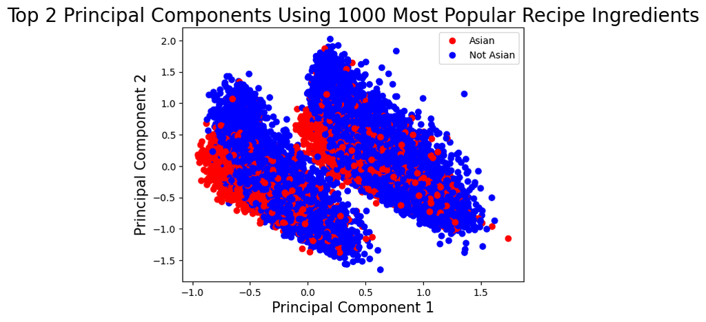

```python
from sklearn import decomposition
import matplotlib.pyplot as plt
from matplotlib.colors import ListedColormap
from sklearn.manifold import TSNE

pca = decomposition.PCA(n_components=2)
X = pca.fit_transform(features)

NUM_COLORS = len(cuisines)
cm = plt.get_cmap('gist_rainbow')

# Build the plot
vals = {cuisine: i for i, cuisine in enumerate(cuisines)}
c = list(map(lambda x: vals[x], labels))
cmap = ListedColormap(['red', 'blue'])
fig, ax = plt.subplots()
scatter = ax.scatter(X[:,0], X[:,1], c=c, cmap=cmap)

# Add labels
ax.set_xlabel('Principal Component 1', fontsize = 15)
ax.set_ylabel('Principal Component 2', fontsize = 15)
ax.set_title('Top 2 Principal Components Using 1000 Most Popular Recipe Ingredients', fontsize = 20)

plt.legend(handles=scatter.legend_elements()[0], labels=cuisines)

plt.show()
```

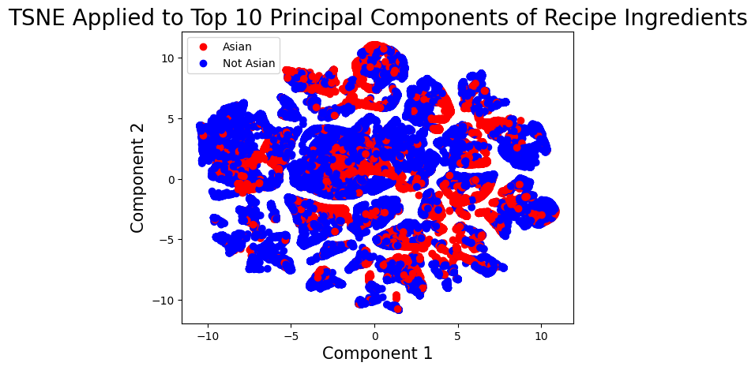

```python
from sklearn import decomposition
import matplotlib.pyplot as plt
from matplotlib.colors import ListedColormap
from sklearn.manifold import TSNE

pca = decomposition.PCA(n_components=10)
pca_result = pca.fit_transform(features)
tsne = TSNE(n_components=2, n_iter=300)
X = tsne.fit_transform(pca_result)

NUM_COLORS = len(cuisines)
cm = plt.get_cmap('gist_rainbow')

# Build the plot
vals = {cuisine: i for i, cuisine in enumerate(cuisines)}
c = list(map(lambda x: vals[x], labels))
cmap = ListedColormap(['red', 'blue'])
fig, ax = plt.subplots()
scatter = ax.scatter(X[:,0], X[:,1], c=c, cmap=cmap)

# Add labels
ax.set_xlabel('Component 1', fontsize = 15)
ax.set_ylabel('Component 2', fontsize = 15)
ax.set_title('TSNE Applied to Top 10 Principal Components of Recipe Ingredients', fontsize = 20)

plt.legend(handles=scatter.legend_elements()[0], labels=cuisines)

plt.show()
```

### Comparison of at least 3 ML models

Logistic Regression, Random Forests, Gradient Boosting, andd Multi-Layer Perceptrons will be used to train classifiers and predict whether recipes originate from asian cuisines or not.

Logistic Regression was selected for a few reasons. First, unlike bayesian classifiers, it makes no assumptions about the distribution of the classes in the space of the features. Second, logistic regression is known to perform well on linear problems, and predicting recipe cuisines based on ingredient lists may be such a problem. Third, logistic regression produces interpretable models, as the coefficients of the features are rough indicators of feature importance.

Random Forests were selected for their strong predictive power. They are able to learn non-linear patterns in the data, and they perform well even without extensive hyperparameter tuning. Additionally, random forests are unlikely to overfit, as they use a subset of observations and features to train ever individual tree, and use "wisdom of the crowd" to make a prediction. Thus, the model is expected to have a relatively low variance. They also produce relatively interpretable feature importance scores, which will assist in task 2.

Gradient Boosting was selected because it is also known to be a strong learner. Specifically, gradient boosting greedily improves on models in an iterative manner, meaning it is likely to produce a model with a high prediction accuracy as well. Similarly to trees, feature importance scores can be obtained from gradient boosting for interpretability.

Mutli-Layer Perceptrons were selected because there is a significant amount of data (>10000 observations per class), and they have the ability to solve complex nonlinear problems. However, their usefulness is likely limited to task 1 alone, as the weights in a MLP are difficult to interpret.

```python
# Separate into train and test data
X = features
y = labels.map(lambda x: 1 if x == 'Asian' else 0)
X_train, X_test, y_train, y_test = train_test_split(X, y, test_size=0.20, random_state=0)
```

```python
# Logistic Regression
from sklearn.linear_model import LogisticRegressionCV

# Tune hyperparameters using 5-fold CV
fit_logistic_regression = LogisticRegressionCV(cv=5, solver='saga', n_jobs=-1, random_state=0).fit(X_train, y_train)
logistic_regression_score = fit_logistic_regression.score(X_test, y_test)
logistic_regression_score
```

```
0.9587680703959773
```

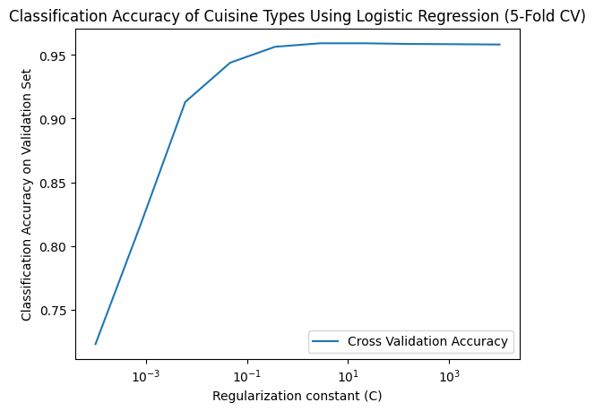

```python
# Aggregate the cross validation accuracies for each C value tested by the library function
scores = fit_logistic_regression.scores_[1]
k = len(scores)
Cs = fit_logistic_regression.Cs_
cv_accuracy = [0 for i in range(len(Cs))]

for i in range(len(scores)):
    for j in range(len(scores[0])):
        cv_accuracy[j] += scores[i][j] / k

# Plot lines
plt.plot(Cs, cv_accuracy, label = "Cross Validation Accuracy")
plt.xscale('log')

# Set labels
plt.xlabel('Regularization constant (C)')
plt.ylabel('Classification Accuracy on Validation Set')
plt.title('Classification Accuracy of Cuisine Types Using Logistic Regression (5-Fold CV)')
plt.legend()
plt.show()
```

```python
from sklearn.ensemble import RandomForestClassifier
import time

# Tuning for Random Forests
start = time.time()
n_estimators = range(50, 400, 100)
max_samples = np.arange(0.25, 1.25, 0.25)
best_estimators, best_oob, best_samples = -1, -1, -1
best_fit = None

for i in n_estimators:
    for k in max_samples:
        fit = RandomForestClassifier(n_estimators=i, max_samples=k, oob_score=True, n_jobs=-1).fit(X_train, y_train)
        if fit.oob_score_ > best_oob:
            best_estimators = i
            best_samples = k
            best_oob = fit.oob_score_
            best_fit = fit

end = time.time()
print('Best number of estimators in ensemble: ', str(best_estimators))
print('Best proportion of observations in each base estimator: ', str(best_samples))
print('Best oob score: ', str(best_oob))
print('Test Accuracy: ', str(best_fit.score(X_test, y_test)))
print('Time Taken: ', str(end - start))
```

```
Best number of estimators in ensemble:  350
Best proportion of observations in each base estimator:  1.0
Best oob score:  0.9509412615104184
Test Accuracy:  0.9508485229415462
Time Taken:  530.6455409526825
```

```python
from sklearn.ensemble import GradientBoostingClassifier

# Gradient Boosting
start = time.time()
learning_rates = np.logspace(-1.0, 3.0, num=5, base=10.0)
subsample = np.arange(0.1, 1.1, 0.1)
n_estimators = [int(i) for i in np.logspace(0.0, 2.0, num=3, base=10.0)]
parameters = {'learning_rate':learning_rates , 'n_estimators': n_estimators, 'subsample': subsample}
fit_gdb = GridSearchCV(GradientBoostingClassifier(random_state=0), parameters, n_jobs=-1).fit(X_train, y_train)
end = time.time()

print('Best model: ' + str(fit_gdb.best_estimator_), fit_gdb.best_params_)
print('Best CV Accuracy: ', str(fit_gdb.best_score_))
print('Test Accuracy: ', str(fit_gdb.score(X_test, y_test)))
print('Time Taken: ', str(end - start))
```

```
Best model: GradientBoostingClassifier(learning_rate=1.0, random_state=0) {'learning_rate': 1.0, 'n_estimators': 100, 'subsample': 1.0}
Best CV Accuracy:  0.949495521968467
Test Accuracy:  0.9518541797611565
Time Taken:  1370.3905398845673
```

```python
import tensorflow as tf
from keras import callbacks
from sklearn.metrics import plot_confusion_matrix

# Split the traiining data into training and validation
X_train2, X_val, y_train2, y_val = train_test_split(X_train, y_train, test_size=0.25, random_state=0)
```

[output not shown]

```python
# Utils for plotting confusion matrices

class estimator:
    _estimator_type = ''
    classes_=[]
    def __init__(self, model, classes):
        self.model = model
        self._estimator_type = 'classifier'
        self.classes_ = classes
    def predict(self, X):
        y_prob= self.model.predict(X)
        y_pred = y_prob.argmax(axis=1)
        return y_pred
```

```python
# MLP with 2 hidden layers
def evaluate_layersize(size1, size2, dropout, results):
    earlystopping = callbacks.EarlyStopping(monitor ="val_loss",
                                        mode ="min", patience = 5,
                                        restore_best_weights = True)

    model = tf.keras.Sequential([
        tf.keras.layers.Flatten(),
        tf.keras.layers.Dense(size1, activation='relu'),
        tf.keras.layers.Dropout(dropout),
        tf.keras.layers.Dense(size2, activation='relu'),
        tf.keras.layers.Dropout(dropout),
        tf.keras.layers.Dense(10, activation='softmax')
    ])
    model.compile(optimizer='adam',
                  loss=tf.keras.losses.SparseCategoricalCrossentropy(from_logits=True),
                  metrics=['accuracy'])
    model.fit(X_train2, y_train2, epochs=25, validation_data=(X_val, y_val), callbacks=[earlystopping])

    # Evaluate results on the validation set
    val_loss, val_acc = model.evaluate(X_val, y_val, verbose=2)
    result = '\nValidation accuracy for layer sizes of ' + str(size1) + ' and ' + str(size2) + 'with dropout ' + str(dropout) + ' : ' + str(val_acc)
    results.append(result)
    print(result)
    return val_acc, model
```

```
249/249 - 0s - loss: 0.1242 - accuracy: 0.9595 - 238ms/epoch - 954us/step

Validation accuracy for layer sizes of 10 and 10with dropout 0.2 : 0.9595223069190979
249/249 - 0s - loss: 0.1246 - accuracy: 0.9571 - 212ms/epoch - 853us/step

Validation accuracy for layer sizes of 10 and 10with dropout 0.4 : 0.9571338891983032
249/249 - 0s - loss: 0.1336 - accuracy: 0.9565 - 244ms/epoch - 980us/step

Validation accuracy for layer sizes of 10 and 10with dropout 0.5 : 0.9565053582191467
249/249 - 0s - loss: 0.1226 - accuracy: 0.9586 - 210ms/epoch - 842us/step

Validation accuracy for layer sizes of 10 and 20with dropout 0.2 : 0.9586423635482788
249/249 - 0s - loss: 0.1228 - accuracy: 0.9576 - 211ms/epoch - 846us/step

Validation accuracy for layer sizes of 10 and 20with dropout 0.4 : 0.9576367139816284
249/249 - 0s - loss: 0.1262 - accuracy: 0.9554 - 210ms/epoch - 843us/step

Validation accuracy for layer sizes of 10 and 20with dropout 0.5 : 0.955374002456665
249/249 - 0s - loss: 0.1208 - accuracy: 0.9591 - 212ms/epoch - 851us/step

Validation accuracy for layer sizes of 10 and 100with dropout 0.2 : 0.959145188331604
249/249 - 0s - loss: 0.1193 - accuracy: 0.9590 - 214ms/epoch - 859us/step

Validation accuracy for layer sizes of 10 and 100with dropout 0.4 : 0.9590194821357727
249/249 - 0s - loss: 0.1195 - accuracy: 0.9579 - 215ms/epoch - 864us/step

Validation accuracy for layer sizes of 10 and 100with dropout 0.5 : 0.957888126373291
249/249 - 0s - loss: 0.1222 - accuracy: 0.9586 - 222ms/epoch - 892us/step

Validation accuracy for layer sizes of 10 and 500with dropout 0.2 : 0.9586423635482788
249/249 - 0s - loss: 0.1195 - accuracy: 0.9569 - 217ms/epoch - 872us/step

Validation accuracy for layer sizes of 10 and 500with dropout 0.4 : 0.9568824768066406
249/249 - 0s - loss: 0.1205 - accuracy: 0.9583 - 221ms/epoch - 886us/step

Validation accuracy for layer sizes of 10 and 500with dropout 0.5 : 0.9582652449607849
249/249 - 0s - loss: 0.1218 - accuracy: 0.9579 - 225ms/epoch - 903us/step

Validation accuracy for layer sizes of 20 and 10with dropout 0.2 : 0.957888126373291
249/249 - 0s - loss: 0.1234 - accuracy: 0.9584 - 228ms/epoch - 914us/step
```

[output cut: 89 more lines]

```
249/249 - 0s - loss: 0.1252 - accuracy: 0.9556 - 344ms/epoch - 1ms/step

Validation accuracy for layer sizes of 500 and 100with dropout 0.4 : 0.9556254148483276
249/249 - 0s - loss: 0.1210 - accuracy: 0.9593 - 342ms/epoch - 1ms/step

Validation accuracy for layer sizes of 500 and 100with dropout 0.5 : 0.9592708945274353
249/249 - 0s - loss: 0.1285 - accuracy: 0.9540 - 380ms/epoch - 2ms/step

Validation accuracy for layer sizes of 500 and 500with dropout 0.2 : 0.953991174697876
249/249 - 0s - loss: 0.1214 - accuracy: 0.9573 - 378ms/epoch - 2ms/step

Validation accuracy for layer sizes of 500 and 500with dropout 0.4 : 0.9572595953941345
249/249 - 0s - loss: 0.1265 - accuracy: 0.9554 - 370ms/epoch - 1ms/step

Validation accuracy for layer sizes of 500 and 500with dropout 0.5 : 0.955374002456665
```

[output not shown]

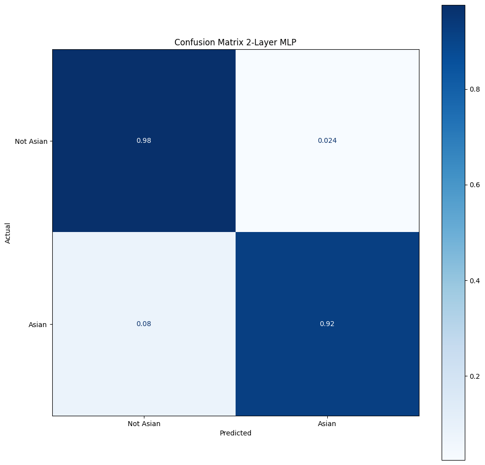

```python
# Find the best hidden layer sizes for a MLP using grid search, including dropout layers
base_size = 1000
neuron_counts = [base_size // 100, base_size // 50, base_size // 10, base_size // 2]
dropouts = [0.2, 0.4, 0.5]

best_accuracy_mlp = 0
best_mlp = None
best_params_mlp = []
results_mlp = []

for i in neuron_counts:
    for j in neuron_counts:
        for k in dropouts:
            accuracy, model = evaluate_layersize(i, j, k, results_mlp)
            if accuracy > best_accuracy_mlp:
                best_accuracy_mlp = accuracy
                best_mlp = model
                best_params_mlp = [i, j, k]

# Plot CM
classifier = estimator(best_mlp, ['Not Asian', 'Asian'])
fig, ax = plt.subplots(figsize=(12,12))
plot_confusion_matrix(estimator=classifier, X=X_test, y_true=y_test, cmap='Blues', normalize='true', display_labels=['Not Asian', 'Asian'], ax=ax)
ax.set(xlabel='Predicted', ylabel='Actual', title='Confusion Matrix 2-Layer MLP')
```

```python
test_loss, test_acc = best_mlp.evaluate(X_test, y_test, verbose=2)

print(best_params_mlp)
print(test_acc)
```

```
249/249 - 0s - loss: 0.1247 - accuracy: 0.9599 - 364ms/epoch - 1ms/step
[500, 20, 0.2]
0.9598994255065918
```

### Validate results using best practices

For Logistic Regression and Gradient Boosting, 5-fold cross validaition was used to tune hyperparameters. For each model, a grid search was performed over a space of potential hyperparameters, and the model with the highest cross validation score was selected. For Random Forests, a grid search was also performed over a space of hyperparameters, and the model was tuned using the best out of bag error. This was used instead of cross validation because the out of bag error provides a built-in method for evaluating models without polluting the data with information from the test set. Finally, MLPs were tuned using a 60/20/20 train/validation/test split, as 5-fold cross validation would have been computationally expensive to perform. I argue this is acceptable, as there are over 10,000 observations per class.

Finally, each model's performance was evaluated on the reserved test set, which is 20% of the original dataset. The classification accuracy for each model is reported below.

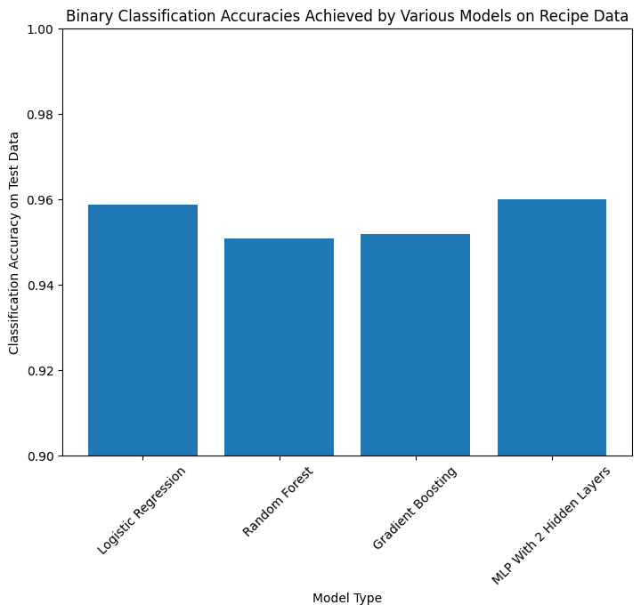

```python
# Models and accuracies
models = ['Logistic Regression', 'Random Forest', 'Gradient Boosting', 'MLP With 2 Hidden Layers']
scores = [0.9587680703959773, 0.9508485229415462, 0.9518541797611565, 0.9598994255065918]

# Plot results
fig = plt.figure()
ax = fig.add_axes([0,0,1,1])
ax.bar(models,scores)

plt.title("Binary Classification Accuracies Achieved by Various Models on Recipe Data")
plt.xlabel("Model Type")
plt.ylabel("Classification Accuracy on Test Data")
plt.ylim(0.90, 1.00)
plt.xticks(rotation = 45) # Rotates X-Axis Ticks by 45-degrees
plt.show()
```

```python
# Analyze best models
best_rfc = best_fit
best_gdb = fit_gdb

best_models = [fit_logistic_regression, best_rfc, best_gdb, best_mlp]
```

```python
# Interpretation for Logistic Regression
ingredients = fit_logistic_regression.feature_names_in_
coefficients = fit_logistic_regression.coef_
ingredients_with_coefficients = sorted([(coefficients[0][i], ingredients[i]) for i in range(len(ingredients))])
print("100 INGREDIENTS WITH LOWEST COEFFICIENTS")
for elem in ingredients_with_coefficients[:100]:
    print(elem)

print("\n100 INGREDIENTS WITH HIGHEST COEFFICIENTS")
for elem in ingredients_with_coefficients[-100:]:
    print(elem)
```

```
100 INGREDIENTS WITH LOWEST COEFFICIENTS
(-7.566190933591636, 'collard greens')
(-5.373888178463512, 'yellow peppers')
(-5.075871224236179, 'tomatillos')
(-4.93253542321623, 'fresh mozzarella')
(-4.887891897681399, 'jack cheese')
(-4.878882429634259, 'green tomatoes')
(-4.789368750663951, 'spanish chorizo')
(-4.780051239170036, 'quickcooking grits')
(-4.7503953403439905, 'flour tortillas')
(-4.519947583828841, 'fish stock')
(-4.514706434616924, 'andouille sausage')
(-4.462997264258147, 'corn tortillas')
(-4.396566361202337, 'cajun seasoning')
(-4.189479497994981, 'bourbon whiskey')
(-4.183943805424018, 'taco seasoning mix')
(-4.169471164663107, 'black-eyed peas')
(-4.162236424930194, 'oregano')
(-4.107967670033046, 'bacon slices')
(-3.864868334754141, 'thyme')
(-3.811475049261159, 'celery seed')
(-3.781368435753405, 'clam juice')
(-3.737255506306593, 'ancho chile pepper')
(-3.7181393209497435, 'creole seasoning')
(-3.715128304978399, 'cachaca')
(-3.6973129494786763, 'fresh rosemary')
(-3.6494579555343023, 'anise seed')
(-3.621944545059715, 'capers')
(-3.6193660741220666, 'dark rum')
(-3.5715012123379064, 'pearl onions')
(-3.5671403105379853, 'masa harina')
(-3.565695459177761, 'monterey jack')
(-3.54682428705684, 'lemon rind')
(-3.5212514393922296, 'preserved lemon')
(-3.4926444498945357, 'dried rosemary')
(-3.480287754647485, 'polenta')
(-3.437849793971542, 'mozzarella cheese')
(-3.4367173567408633, 'salsa')
(-3.3931179242317424, 'artichok heart marin')
(-3.381673943372155, 'tequila')
```

[output cut: 148 more lines]

```
(5.03444001771963, 'bok choy')
(5.2161005538424865, 'edamame')
(5.233323979433468, 'rice paper')
(5.24839559484324, 'konbu')
(5.366157026689697, 'kimchi')
(5.4758163970621965, 'thai chile')
(5.581132174465842, 'Thai fish sauce')
(5.636237979129408, 'masala')
(5.7447067471376885, 'daikon')
(5.7694017117803735, 'sushi rice')
(5.816820018128965, 'fish sauce')
(5.966638197631045, 'spring roll wrappers')
(6.198418698065396, 'asian fish sauce')
(6.272364008123512, 'red curry paste')
(7.408197742452477, 'Thai red curry paste')
```

```python
# Interpretation for Random Forests and Gradient Boosting
def get_feature_importance_names(f):
    x = list(zip(f, X_train.columns))
    x.sort(reverse = True, key = lambda e: e[0])
    return [e[1] for e in x]

def get_feature_importances(f):
    x = list(zip(f, X_train.columns))
    x.sort(reverse = True, key = lambda e: e[0])
    return [e[0] for e in x]

print("TOP 100 MOST IMPORTANT FEATURES")
print(f"{'GRADIENT BOOSTING':<40}{'RANDOM FOREST':<40}")
print("\n".join(map(lambda e: f"{e[0]:<40}{e[1]:<40}",
    zip(get_feature_importance_names(best_gdb.best_estimator_.feature_importances_)[:100],
        get_feature_importance_names(best_rfc.feature_importances_)[:100]))))

print("\nFEATURE IMPORTANCE SCORES OF 100 MOST IMPORTANT FEATURES")
print(f"{'GRADIENT BOOSTING':<40}{'RANDOM FOREST':<40}")
print("\n".join(map(lambda e: f"{e[0]:<40}{e[1]:<40}",
    zip(get_feature_importances(best_gdb.best_estimator_.feature_importances_)[:100],
        get_feature_importances(best_rfc.feature_importances_)[:100]))))
```

```
TOP 100 MOST IMPORTANT FEATURES
GRADIENT BOOSTING                       RANDOM FOREST
soy sauce                               soy sauce
fish sauce                              fish sauce
garam masala                            sesame oil
ginger                                  ginger
fresh ginger                            fresh ginger
low sodium soy sauce                    rice vinegar
olive oil                               garam masala
ground turmeric                         oil
curry powder                            ground turmeric
sesame oil                              coconut milk
light soy sauce                         curry powder
rice vinegar                            cumin seed
ghee                                    olive oil
oil                                     mirin
coconut milk                            peeled fresh ginger
asian fish sauce                        scallions
cumin seed                              corn starch
Thai fish sauce                         oyster sauce
ground allspice                         ghee
extra-virgin olive oil                  beansprouts
mirin                                   low sodium soy sauce
ground cardamom                         sesame seeds
peeled fresh ginger                     hoisin sauce
butter                                  tumeric
dried oregano                           sake
unsalted butter                         vegetable oil
corn tortillas                          light soy sauce
rice flour                              lemongrass
fresh ginger root                       water
evaporated milk                         sugar
basmati rice                            toasted sesame oil
tofu                                    butter
dried thyme                             salt
plain yogurt                            extra-virgin olive oil
toasted sesame oil                      all-purpose flour
sesame seeds                            red chili peppers
oyster sauce                            fresh ginger root
sweetened condensed milk                dark soy sauce
```

[output cut: 150 more lines]

```
0.0005881982399406399                   0.0018747264128873083
0.0005797767429847137                   0.001869244757846369
0.0005739900434764022                   0.0018689975452107445
0.0005731241363567038                   0.0018604952899126089
0.0005647507826463253                   0.0018542796490577196
0.0005628058317408951                   0.0018494093308703081
0.0005595285724041109                   0.0018424639098192567
0.0005584834616985979                   0.0018343217523056673
0.0005575331618668314                   0.001825565104572105
0.0005443735451951801                   0.0018239414271007627
0.0005402625692466751                   0.0017751166237543168
0.0005345441864704332                   0.0017427647090681344
0.0005121282331313639                   0.0017423101533204578
0.0005117640807659398                   0.0017402304088021104
0.0005040564184041205                   0.0016948135954882489
```

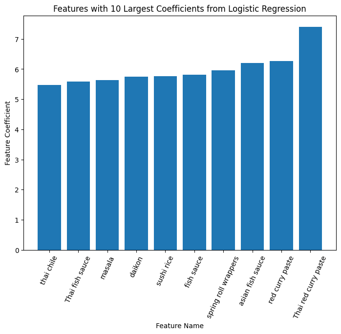

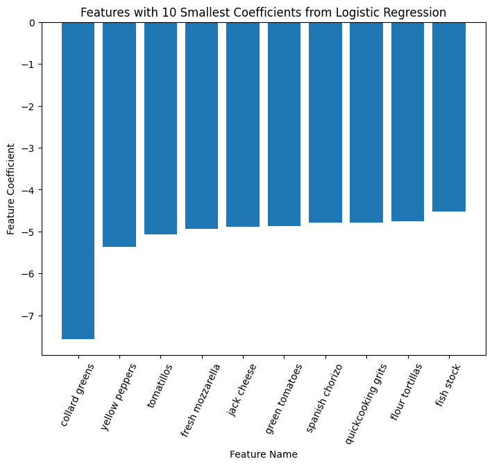

```python
# Visualize feature importances for all models
fig = plt.figure()
ax = fig.add_axes([0,0,1,1])
ax.bar([i[1] for i in ingredients_with_coefficients[-10:]],[i[0] for i in ingredients_with_coefficients[-10:]])

plt.title("Features with 10 Largest Coefficients from Logistic Regression")
plt.xlabel("Feature Name")
plt.ylabel("Feature Coefficient")
plt.xticks(rotation = 65) # Rotates X-Axis Ticks by 45-degrees
plt.show()

fig = plt.figure()
ax = fig.add_axes([0,0,1,1])
ax.bar([i[1] for i in ingredients_with_coefficients[:10]],[i[0] for i in ingredients_with_coefficients[:10]])

plt.title("Features with 10 Smallest Coefficients from Logistic Regression")
plt.xlabel("Feature Name")
plt.ylabel("Feature Coefficient")
plt.xticks(rotation = 65) # Rotates X-Axis Ticks by 45-degrees
plt.show()
```

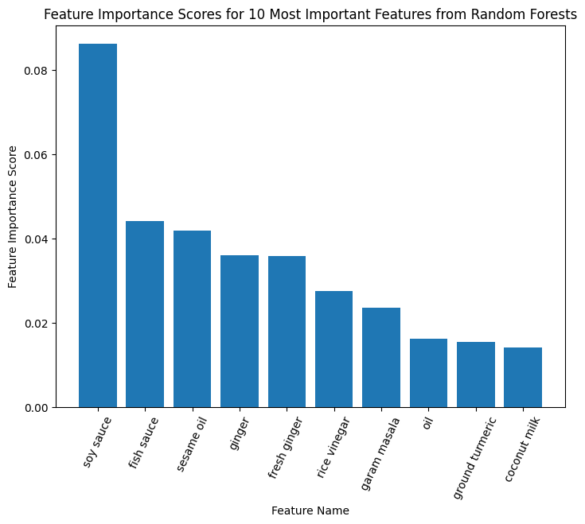

```python
fig = plt.figure()
ax = fig.add_axes([0,0,1,1])
ax.bar(get_feature_importance_names(best_rfc.feature_importances_)[:10],get_feature_importances(best_rfc.feature_importances_)[:10])

plt.title("Feature Importance Scores for 10 Most Important Features from Random Forests")
plt.xlabel("Feature Name")
plt.ylabel("Feature Importance Score")
plt.xticks(rotation = 65) # Rotates X-Axis Ticks by 45-degrees
plt.show()
```

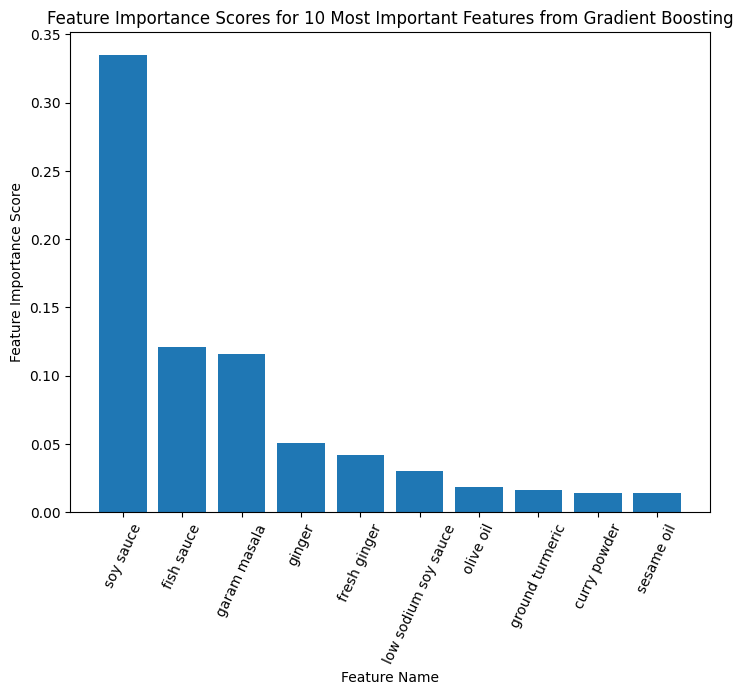

```python
fig = plt.figure()
ax = fig.add_axes([0,0,1,1])
ax.bar(get_feature_importance_names(best_gdb.best_estimator_.feature_importances_)[:10],get_feature_importances(best_gdb.best_estimator_.feature_importances_)[:10])

plt.title("Feature Importance Scores for 10 Most Important Features from Gradient Boosting")
plt.xlabel("Feature Name")
plt.ylabel("Feature Importance Score")
plt.xticks(rotation = 65) # Rotates X-Axis Ticks by 45-degrees
plt.show()
```

### Interpret results and draw conclusions

Above, the features with the highest coefficient magnitudes from logistic regression are displayed. The features with the highest importance scores for random forests and gradient boosting are also listed. As expected, there are ingredients that are distinctly Asian, and not all ingredients are equally useful for determining whether a recipe is from an Asian cuisine or not.

In addition to identifying ingredients that are distinctly asian, the logistic regression also helps interpret which ingredients are explicitly not Asian. For example, collared greens, yellow peppers, and mozzarella cheese are among the features with the most negative coefficients. This can be interpreted to mean that the presence of these ingredients (along with other ingredients with large negative coefficients) descreases the odds that a recipe is predicted to be from an Asian cuisine.

In conclusion, it appears that recipe ingredients are useful features for predicting whether a recipe is from an asian cuisine or not. Specifically, the presence of soy sauce and fish sauce in a recipe are strong indicators that a recipe may be from an Asian cuisine. Additionally, there are ingredients that can be identified as distinctly not Asian. For example, we would expect tomatillos and masa to be part of Mexican recipes, but not part of Asian recipes, and the classifiers confirm this concept. Additionally, some ingredients may be shared among Asian and non-Asian cuisines. These ingredients may be identified by examining features whose coefficients have a very small magnitude in the logistic regression model and the features that have low feature importance scores in the tree based models.